# Valorant Winnings Prediction

Joshua Liao

Due March 19th, 2023

### Background

Professional VALORANT is a competitive esports scene centered around the popular team-based first-person shooter game VALORANT. In professional VALORANT, teams of five players compete against each other in various tournaments and leagues for prize money, trophies, and recognition.

The game is played on a round-by-round basis, with each round consisting of a team of attackers trying to plant a bomb (the Spike) at one of several designated locations, while the defending team tries to prevent the bomb from being planted or defuse it if it has been planted. The first team to win 13 rounds wins the match.

Professional VALORANT teams typically consist of highly skilled and experienced players who have developed their skills through rigorous training and practice. Teams often have specific roles, such as entry fraggers, support players, and in-game leaders, and work together to execute complex strategies and outplay their opponents.

There are several professional VALORANT leagues and tournaments, including the Riot Games’ official VALORANT Champions Tour, which features various regional competitions culminating in a global championship, as well as third-party events organized by other esports organizations. The professional VALORANT scene continues to grow in popularity, with increasing numbers of players and viewers worldwide, and promises to be a significant force in the world of competitive esports in the years to come.

[figure not shown]

Fig 1. VCT Stage, The World Championship for Valorant

### Overview of research question

The idea of this project is to take competitive game statistics of current professional Valorant Esports players to obtain a model to predict their success in Esports in terms of monetary value. The current winnings are numeric in value and offer a clear picture in the success of a player. A win is not necessarily dependent on any particular predictor variable and instead can be a combination of them. These questions will be answered best through regression. This model will be predictive in nature as it will allow us to assess the probable success of future professional players based on limited statistics.

[figure not shown]

Fig 2. My Good Buddy Sentinel Tenz

### Importing and Cleaning Datasets

The first step is to import and clean the data from vlr.gg/stats. The player statistics dataset was obtained by having Python read the html table element then creating a dataframe. For the winnings, BeautifulSoup was used to scrape the data from the VLR website since the winnings were not included on the table and instead on each player’s personal profile. Lastly for team and country, the data was obtained by creating a dataset from selecting the html elements within the table to input into a new dataframe. Both Python files are included in the .zip file.

```r
#Here we read in the csv files
playerwinnings<-read.csv("data/player_winnings_full.csv")
playerstats<-read.csv("data/vlr.csv")
playerteam<-read.csv("data/playerandteam.csv")
playercountry<-read.csv("data/playerandcountry.csv")

#Since the csv's do not have overlapping columns, we append the Player variable to match player_short
words <- strsplit(playerstats$Player, "\\s+")
playerstats$player_short <- sapply(words, function(x) ifelse(length(x) > 1, paste(x[-length(x)], collapse = " "), x))
playerwinnings<-playerwinnings%>%select(player_short, winnings)
playerwinnings$winnings <- as.numeric(gsub("[^0-9\\.]+", "", playerwinnings$winnings))

#Here we match our "by" variable in each dataset so we can merge
playerstats$player_short<-tolower(playerstats$player_short)
playerteam$player_short<-tolower(playerteam$player_short)
playercountry$player_short<-tolower(playercountry$player_short)

#Merging the datasets
vlrdata<-merge(playerstats, playerwinnings, by = "player_short")
vlrdata<-merge(vlrdata, playerteam, by="player_short")
vlrdata<-merge(vlrdata, playercountry, by="player_short")

#Capitalize country code (For aesthetic purposes)
vlrdata$Country<-toupper(vlrdata$Country)

#Here I noticed that there were duplicated rows due to some players switching teams, so I removed the duplicated rows
duplicated_rows <- duplicated(vlrdata[, c("player_short", "winnings")])
vlrdata <- subset(vlrdata, !duplicated_rows)

#These variables were in character format and I changed them to numeric
vlrdata$KAST <- as.numeric(gsub("%", "", vlrdata$KAST))/100
vlrdata$HS. <- as.numeric(gsub("%", "", vlrdata$HS.))/100
vlrdata$CL. <- as.numeric(gsub("%", "", vlrdata$CL.))/100
vlrdata$winnings <- as.integer(vlrdata$winnings)

#Removing irrelevant columns
vlrdata<-vlrdata%>%select(-Player, -Agents, -CL)

#Mutating the Team variable so that we can use it as a predictor
vlrdata<-vlrdata%>%
  mutate(Team=factor(Team))
```

The final codebook is included in the .zip file.

### Exploratory Data Analysis

Here a lot of our exploratory Data Analysis will go towards analyzing the distribution of our target variable, winnings. First we start off with a simple histogram to better visualize the distribution.

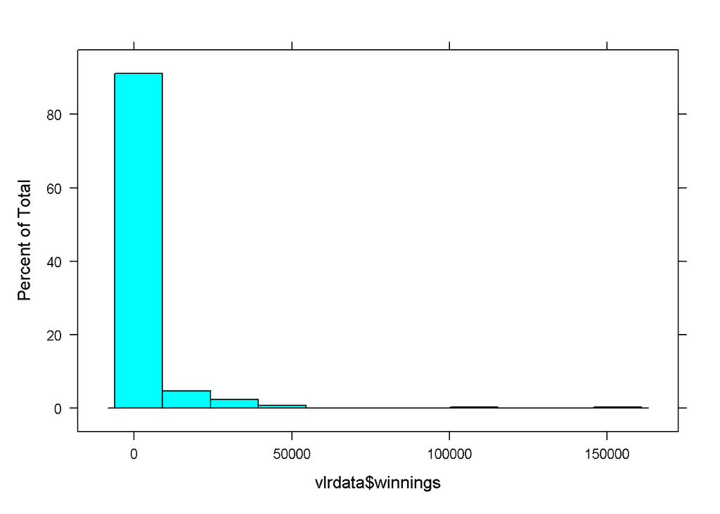

```r
histogram(x=vlrdata$winnings)
```

It seems the distribution is incredibly zero-inflated making it hard for us to easily apply any kind of shape to it. I’ll apply a log function to the target variable to see if we can get a nicer shaped distribution.

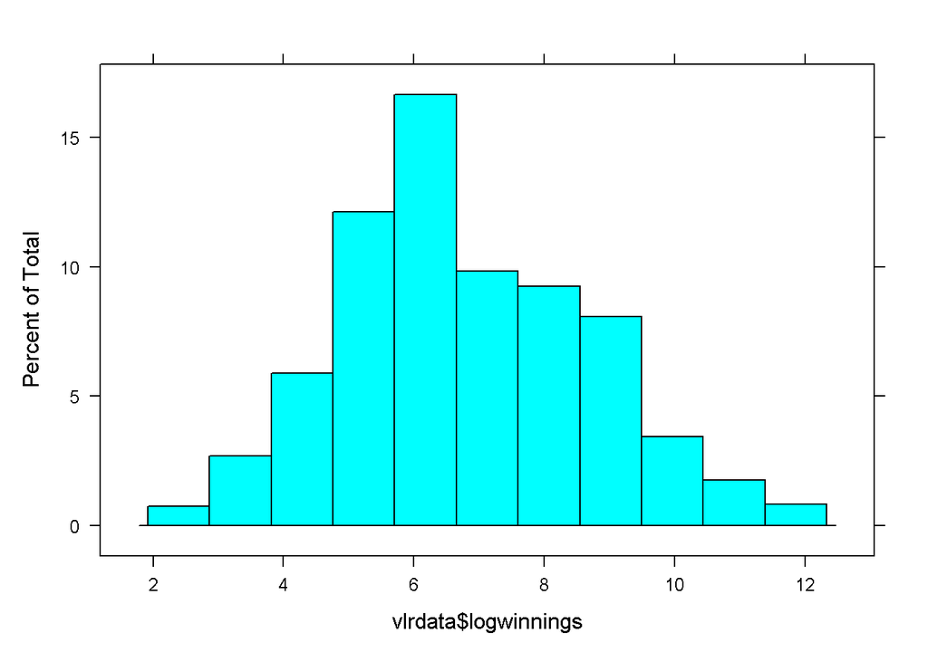

```r
# We add 1 so that the entries with 0 are included
vlrdata$logwinnings <- log(vlrdata$winnings)
histogram(x=vlrdata$logwinnings)
```

Looking at this there doesn’t seem to be a specific model that is easily applicable to this data distribution. I’ll try removing the zero’s to see if it will normalize.

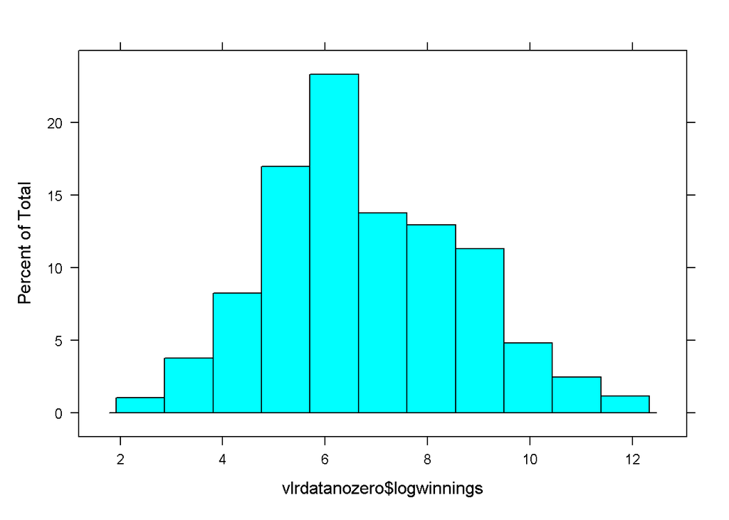

```r
vlrdatanozero<- subset(vlrdata, !vlrdata$winnings==0)
histogram(x=vlrdatanozero$logwinnings)
```

Here we have a nicely shaped distribution that our models can work with. Dropping the zeros will impact the general applicability of the model, but it’ll be a limitation of this project that we can deal with.

We can also look at some of the descriptive statistics in the dataset as well to obtain information to the numeric predictor variables.

```r
summary(vlrdatanozero)
```

```
##  player_short            Rnd               R               ACS
##  Length:848         Min.   : 200.0   Min.   :0.3700   Min.   :123.3
##  Class :character   1st Qu.: 570.8   1st Qu.:0.8500   1st Qu.:178.7
##  Mode  :character   Median :1371.5   Median :0.9200   Median :192.2
##                     Mean   :2077.3   Mean   :0.9159   Mean   :193.1
##                     3rd Qu.:3121.5   3rd Qu.:1.0000   3rd Qu.:207.1
##                     Max.   :8110.0   Max.   :1.3200   Max.   :278.9
##                                      NA's   :12
##       K.D              KAST            ADR             KPR
##  Min.   :0.4000   Min.   :0.350   Min.   : 83.0   Min.   :0.3700
##  1st Qu.:0.8100   1st Qu.:0.650   1st Qu.:117.9   1st Qu.:0.6100
##  Median :0.9000   Median :0.680   Median :126.6   Median :0.6700
##  Mean   :0.9031   Mean   :0.679   Mean   :126.7   Mean   :0.6689
##  3rd Qu.:0.9900   3rd Qu.:0.710   3rd Qu.:135.2   3rd Qu.:0.7200
##  Max.   :1.5300   Max.   :0.780   Max.   :177.1   Max.   :1.0000
##                   NA's   :12
##       APR              FKPR              FDPR             HS.
##  Min.   :0.0800   Min.   :0.01000   Min.   :0.0300   Min.   :0.1200
##  1st Qu.:0.2100   1st Qu.:0.06000   1st Qu.:0.0800   1st Qu.:0.2100
##  Median :0.2600   Median :0.08000   Median :0.1000   Median :0.2400
##  Mean   :0.2587   Mean   :0.09315   Mean   :0.1053   Mean   :0.2369
##  3rd Qu.:0.3100   3rd Qu.:0.12000   3rd Qu.:0.1300   3rd Qu.:0.2600
##  Max.   :0.4500   Max.   :0.20000   Max.   :0.2700   Max.   :0.3900
##
##       CL.              KMax             K                D
##  Min.   :0.0200   Min.   : 9.00   Min.   :  75.0   Min.   : 129.0
##  1st Qu.:0.1100   1st Qu.:24.00   1st Qu.: 351.2   1st Qu.: 440.8
##  Median :0.1300   Median :28.00   Median : 944.0   Median :1060.5
##  Mean   :0.1309   Mean   :27.86   Mean   :1442.5   Mean   :1505.1
##  3rd Qu.:0.1500   3rd Qu.:31.00   3rd Qu.:2224.5   3rd Qu.:2262.0
##  Max.   :0.3100   Max.   :48.00   Max.   :6084.0   Max.   :5898.0
##  NA's   :4
##        A                FK                FD            winnings
##  Min.   :  18.0   Min.   :   4.00   Min.   :   7.0   Min.   :    10
##  1st Qu.: 141.0   1st Qu.:  48.75   1st Qu.:  58.0   1st Qu.:   250
##  Median : 331.0   Median : 117.00   Median : 142.0   Median :   612
##  Mean   : 548.1   Mean   : 203.67   Mean   : 211.5   Mean   :  5353
##  3rd Qu.: 779.5   3rd Qu.: 301.00   3rd Qu.: 311.8   3rd Qu.:  3605
##  Max.   :2638.0   Max.   :1133.00   Max.   :1101.0   Max.   :154650
##
##       Team       Country           logwinnings
##         : 92   Length:848         Min.   : 2.303
##  YFP    : 19   Class :character   1st Qu.: 5.521
##  100T   : 10   Mode  :character   Median : 6.417
##  EG     : 10                      Mean   : 6.763
##  MFC    : 10                      3rd Qu.: 8.190
##  (Other):702                      Max.   :11.949
##  NA's   :  5
```

### Graphs of univariate, multivariate relationships between outcome and predictor(s) or between predictors

When thinking about the amount of money a player has made in playing tournaments, one would assume that the amount of rounds they have played will increase the likelihood of winnings right? Here we plot logwinnings against rounds played to see if there is a relationship.

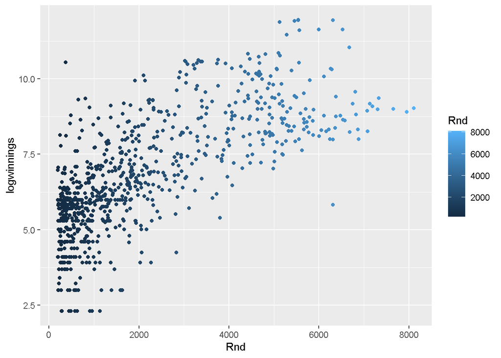

```r
vlrdatanozero %>% ggplot() + aes(x=Rnd, y=logwinnings, color=Rnd)+geom_point()
```

We can see that Rounds played does have a linear correlation with logwinnings.

Next, I want to see whether Average Combat Score has a relationship with Kills, which is a general assumption.

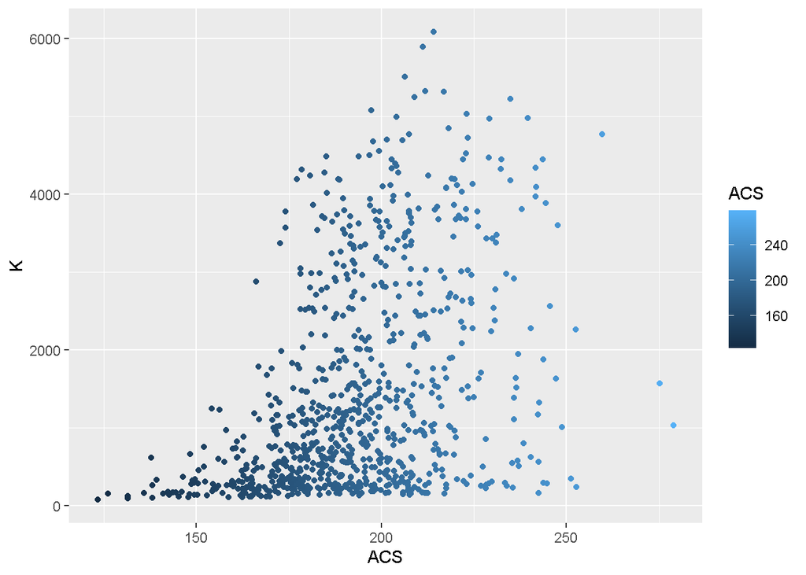

```r
vlrdatanozero %>% ggplot() + aes(x=ACS, y=K, color=ACS)+geom_point()
```

Surprisingly Kills do not have that much of an impact on ACS. This is surprising because one assumes that combat score is indicative of Kills.

### Setting Up Our Model

In order to begin building our model, we first stratify the data by country to ensure that each region is adequately represented, as different regions signify varying tournaments and cash values. Then we take the split and create a training and testing set.

```r
set.seed(123)
vlr_split<-initial_split(vlrdatanozero, prop=0.75, strata=Country)
vlr_train<-training(vlr_split)
vlr_test<-testing(vlr_split)
dim(vlr_train)
```

```
## [1] 635  23
```

```r
dim(vlr_test)
```

```
## [1] 213  23
```

Next, we use *v*-fold cross-validation on the training set using 5 folds and again stratifying on country. The advantage of v-fold cross-validation is that it provides a more accurate estimate of model performance than simply splitting the data into a single training and validation set. This is because it uses all available data for training and validation, rather than just a single split of the data. It also reduces the variance of the estimate by averaging over multiple folds, which can be particularly useful when the dataset is small.

```r
set.seed(123)
vlr_fold<- vfold_cv(data = vlr_train, v = 5, strata = Country)
```

Now that we have the data set up for the model, I wanted to see which variables performed the best in the Variable Importance Plot in order to select the variables to include.

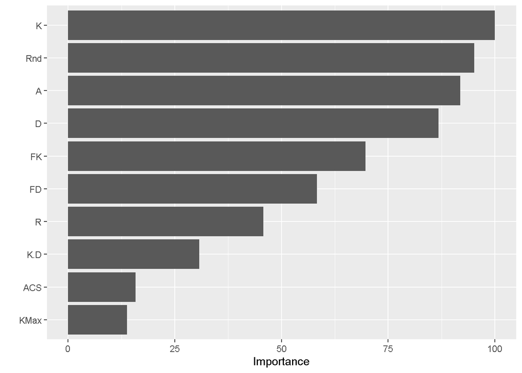

```r
model <- train(logwinnings~Rnd+R+ACS+K.D+ADR+KPR+APR+FKPR+FDPR+KMax+K+D+A+FK+FD, data = na.omit(vlr_train), method = "rf")
vip(model, bar="horizontal", main="Variable Importance Plot")
```

Here we create a correlation plot of all the variables in the training set to analyze whether certain variables are colinear.

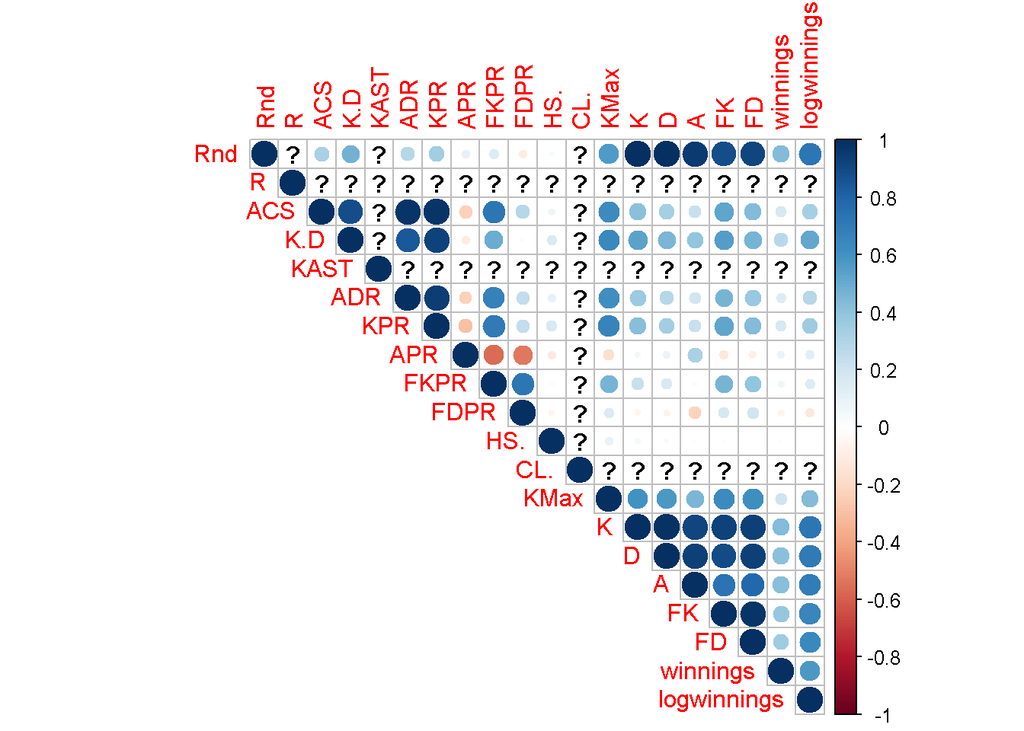

```r
num_vars <- names(vlr_train)[sapply(vlr_train, is.numeric)]
corr <- cor(vlr_train[, num_vars])
corrplot(corr, type="upper")
```

The correlation plot shows us that several variables are highly colinear, which gives us reference to which features we should omit from our final recipe.

### Model Building

Now we finally get to the bread and butter of the project. To start things off, using the features I selected in the last section I create a recipe for all of the models that I intend to test.

```r
recipe_vlr<-recipe(logwinnings~A+K+Rnd+D+FD+FK+R+K.D+Team, vlr_train)%>%
  step_center(all_numeric_predictors())%>%
  step_scale(all_numeric_predictors())%>%
  step_dummy(Team)%>%
  step_impute_mean(all_numeric_predictors()) %>%
  step_normalize(all_numeric_predictors())
```

I started with a linear regression model, which is a popular model for predicting continuous dependent variables that have a linear relationship with the independent variables. If the dependent variable follows a normal distribution, linear regression could be a good choice.

```r
linmodel <- linear_reg() %>%
  set_engine("lm")%>%
  set_mode("regression")

linworkflow <- workflow() %>%
  add_recipe(recipe_vlr) %>%
  add_model(linmodel)
```

Next I chose Elastic Net regression which can be a good choice for predicting Valorant pro player winnings, especially if there are a large number of predictors that may be correlated with each other.

```r
elasticnet <- linear_reg(penalty = tune(), mixture = tune()) %>%
  set_mode("regression") %>%
  set_engine("glmnet", standardize = FALSE)

enworkflow <- workflow() %>%
  add_recipe(recipe_vlr) %>%
  add_model(elasticnet)

engrid <- grid_regular(
  penalty(),
  mixture(),
  levels = 20)
```

After that I chose Random Forest which can handle a large number of predictors, including both categorical and continuous variables, and can effectively capture nonlinear and interaction effects among predictors. It can also handle missing data, as it uses only the available predictors for each split.

Mtry is a parameter that specifies the number of variables randomly sampled as candidates at each split when building a random forest model.

Trees is a parameter specifies the number of trees to be grown in the forest. Min_n is a parameter specifies the minimum number of samples required to be present in a leaf node.

```r
rfmodel <- rand_forest(mtry=tune(), trees=tune(), min_n=tune()) %>%
  set_engine("ranger") %>%
  set_mode("regression")

rfworkflow <- workflow() %>%
    add_recipe(recipe_vlr) %>%
    add_model(rfmodel)

rfgrid <- grid_regular(
  mtry(range = c(1, 9)),
  trees(range = c(1, 400)),
  min_n(range = c(2, 20)),
  levels = 10)
```

Next, we use the fit_resamples() and tune_grid() functions in R to fit and evaluate the performance of the linear regression, random forest, and Elastic Net regression models created earlier.

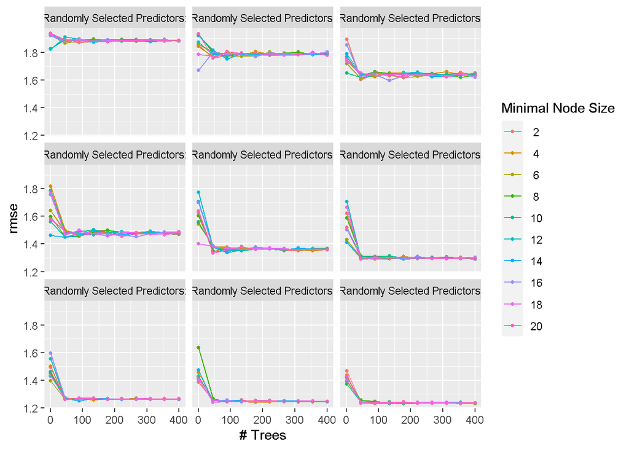

```r
lin_results<- fit_resamples(linworkflow, vlr_fold, metrics = metric_set(rmse))

rf_results <- tune_grid(rfworkflow, resamples = vlr_fold, grid = rfgrid, metrics = metric_set(rmse), control = control_grid(verbose = TRUE))
autoplot(rf_results)
```

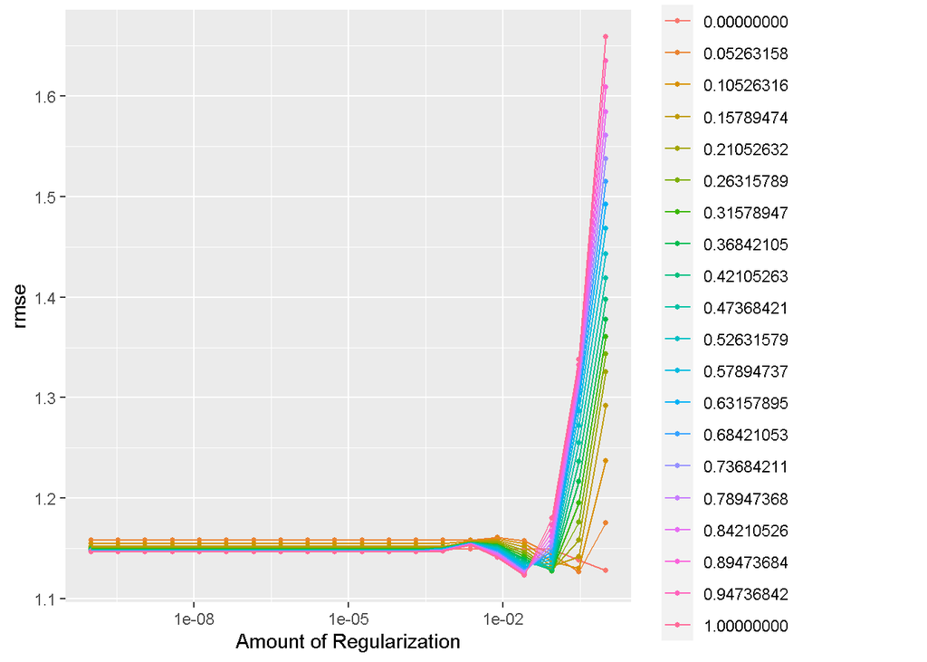

```r
en_results <- tune_grid(enworkflow, resamples = vlr_fold, grid = engrid, metrics = metric_set(rmse), control = control_grid(verbose = TRUE))
autoplot(en_results)
```

Here we choose the best performing from each of our models using the criteria of RMSE.

```r
lin_best <- select_best(lin_results, "rmse")
rf_best <- select_best(rf_results, "rmse")
en_best <- select_best(en_results, "rmse")
```

Using the ‘finalize_workflow’ function to create the final workflow for each model using the best model parameters (lin_best, rf_best, and en_best), then using the fit function to fit the final workflow to the training data (vlr_train), we finally use the augment function to obtain predicted values for the test data (vlr_test).

```r
lin_final <- finalize_workflow(linworkflow, lin_best)
lin_final_fit <- fit(lin_final, data = vlr_train)
linpredicted_data <- augment(lin_final_fit, new_data = vlr_test) %>%
  select(logwinnings, starts_with(".pred"))

rf_final <- finalize_workflow(rfworkflow, rf_best)
rf_final_fit <- fit(rf_final, data = vlr_train)
rfpredicted_data <- augment(rf_final_fit, new_data = vlr_test) %>%
  select(logwinnings, starts_with(".pred"))

en_final <- finalize_workflow(enworkflow, en_best)
en_final_fit <- fit(en_final, data = vlr_train)
enpredicted_data <- augment(en_final_fit, new_data = vlr_test) %>%
  select(logwinnings, starts_with(".pred"))
```

### Model Selection and Performance

Now that we’ve put our models against the testing data, we can assess the performance of each model using Mean Squared Error, RMSE, and R-Squared.

```r
#Here I define each of the functions I want in the global R environment
  datamse <- function(actual, predicted)mean((actual - predicted)^2)

  datarmse <- function(actual, predicted)
    sqrt(datamse(actual, predicted))

  datarsq <- function(actual, predicted) {
    1 - sum((actual - predicted)^2)/sum((actual - mean(actual))^2)}
  datamae <- function(actual, predicted) {
  mean(abs(actual - predicted))}

#Linear Regression Performance
linmse <- datamse(linpredicted_data$logwinnings, linpredicted_data$.pred)
linrmse <- datarmse(linpredicted_data$logwinnings, linpredicted_data$.pred)
linr2 <- datarsq(linpredicted_data$logwinnings, linpredicted_data$.pred)
linmae <- datamae(linpredicted_data$logwinnings, linpredicted_data$.pred)
cat(sprintf("MSE: %.2f\nRMSE: %.2f\nR-squared: %.2f\nMAE: %2f", linmse, linrmse, linr2, linmae))
```

```
## MSE: 1.25
## RMSE: 1.12
## R-squared: 0.64
## MAE: 0.823054
```

```r
#Random Forest Performance
rfmse <- datamse(rfpredicted_data$logwinnings, rfpredicted_data$.pred)
rfrmse <- datarmse(rfpredicted_data$logwinnings, rfpredicted_data$.pred)
rfr2 <- datarsq(rfpredicted_data$logwinnings, rfpredicted_data$.pred)
rfmae <- datamae(rfpredicted_data$logwinnings, rfpredicted_data$.pred)
cat(sprintf("MSE: %.2f\nRMSE: %.2f\nR-squared: %.2f\nMAE: %2f", rfmse, rfrmse, rfr2, rfmae))
```

```
## MSE: 1.36
## RMSE: 1.17
## R-squared: 0.60
## MAE: 0.857215
```

```r
#Elastic Net Performance
enmse <- datamse(enpredicted_data$logwinnings, enpredicted_data$.pred)
enrmse <- datarmse(enpredicted_data$logwinnings, enpredicted_data$.pred)
enr2 <- datarsq(enpredicted_data$logwinnings, enpredicted_data$.pred)
enmae <- datamae(enpredicted_data$logwinnings, enpredicted_data$.pred)
cat(sprintf("MSE: %.2f\nRMSE: %.2f\nR-squared: %.2f\nMAE: %2f", enmse, enrmse, enr2, enmae))
```

```
## MSE: 1.13
## RMSE: 1.06
## R-squared: 0.67
## MAE: 0.784765
```

```r
pmodel <- c("Linear Regression", "Random Forest", "Elastic Net")
pmse <- c(linmse, rfmse, enmse)
prmse <- c(linrmse, rfrmse, enrmse)
pr2 <- c(linr2, rfr2, enr2)
pmae <- c(linmae, rfmae, enmae)
pdf <- data.frame(pmodel, pmse, prmse, pr2, pmae)

# Use the kable function to create a nicely formatted table
kable(pdf, align = "c", caption = "Performance metrics for three models") %>%
  kable_styling(bootstrap_options = c("striped", "hover", "condensed", "responsive"))
```

Performance metrics for three models

| pmodel | pmse | prmse | pr2 | pmae |
| --- | --- | --- | --- | --- |
| Linear Regression | 1.247483 | 1.116908 | 0.6375684 | 0.8230543 |
| Random Forest | 1.364851 | 1.168268 | 0.6034693 | 0.8572151 |
| Elastic Net | 1.125748 | 1.061013 | 0.6729359 | 0.7847647 |

From these performance metrics we can select Elastic Net as the best model to use in our case of valorant winnings.

The R-squared value of 0.67 indicates that approximately 67% of the variance in the target variable can be explained by the model. This means that the model is able to capture some of the variability in the data, but there is still a significant amount of variability that is not accounted for by the model.

### Conclusion

#### Does this model fulfill our project’s purpose?

In terms of predicting Valorant winnings, the performance of the model is reasonable but not perfect. The error rate of the model is relatively low, which suggests that it can be useful for making predictions. However, the R-squared value indicates that there is still a significant amount of unexplained variability in the data, and the model may not be able to capture all the factors that influence Valorant winnings. The benefit of this model however, is that its simplicity makes it easy and cheap to implement.

It’s also important to consider the context in which the model is being used. For example, if the model is being used to predict Valorant winnings for professional players, the model’s performance may be different when applied to amateur or semi-professional players. Additionally, the model can only be applied to players who have already won games, so those who haven’t won anything cannot be included in this model.